# 제21대 국회의원 선거

성남시 분당구 - 데이터/지도

xwMOOC

2019-03-13

# 1 역대선거 득표 데이터

## 1.1 총선 → 대선 → 지선

`krvotes` 팩키지에서 준비된 총선, 대선, 지선 데이터를 바탕으로 분당구 득표 데이터를 비교가능하도록 정당별로 준비시킨다.

- 2016년 총선 분당을의 경우 무소속 임태희 후보는 자한당으로 넣어 데이터를 준비한다.
  - 민주당: 더불어민주당 김병관 + 더불어민주당 김병욱
  - 자한당: 새누리당 권혁세 + 새누리당 전하진 + 무소속 임태희
  - 바른미래당: 국민의당 염오봉 + 국민의당 윤은숙
- 2017년 대선 유승민과 안철수는 합쳐서 바른미래당으로 준비한다.
  - 바른미래당: 안철수 + 유승민
- 2018년 시도지사선거, 경기도지사 득표수로 갈음
  - 이재명, 남경필, 김영환, 이홍우

```r
library(tidyverse)
library(krvotes)

# 총선 2016 -----
`총선_df` <- congress_2018 %>%
  filter(str_detect(`precinct`, "분당")) %>%
  unnest(data_clean) %>%
  group_by(`읍면동명`) %>%
  summarise(`민주당` = sum(`더불어민주당 김병관`, `더불어민주당 김병욱`, na.rm=TRUE),
            `자한당` = sum(`새누리당 권혁세`, `새누리당 전하진`, `무소속 임태희`, na.rm=TRUE),
            `바미당` = sum(`국민의당 염오봉`, `국민의당 윤은숙`, na.rm=TRUE)) %>%
  mutate(`선거` = "2016총선")

# 대선 2017 -----
`대선_df` <- president %>%
  tbl_df %>%
  filter(str_detect(`구시군명`, "분당")) %>%
  group_by(`읍면동명`) %>%
  summarise(`민주당` = sum(`문재인`),
            `자한당` = sum(`홍준표`),
            `바미당` = sum(`안철수`, `유승민`),
            `정의당` = sum(`심상정`)) %>%
  mutate(`선거` = "2017대선")


# 지선 2018 -----
`지선_df` <- local_2018 %>%
  filter(str_detect(`시도명`, "경기")) %>%
  select(-`시도명`) %>%
  unnest(data_clean) %>%
  filter(str_detect(`구시군명`, "분당")) %>%
  group_by(`읍면동명`) %>%
  summarise(`민주당` = sum(`더불어민주당 이재명`),
            `자한당` = sum(`자유한국당 남경필`),
            `바미당` = sum(`바른미래당 김영환`),
            `정의당` = sum(`정의당 이홍우`)) %>%
  mutate(`선거` = "2018지선")

`분당_df` <- bind_rows(`총선_df`, `대선_df`) %>%
  bind_rows(`지선_df`) %>%
  filter(!str_detect(`읍면동명`, "잘못")) %>%
  mutate(`정의당` = ifelse(is.na(`정의당`), 0, `정의당`)) %>%
  select(`선거`, everything())
```

## 1.2 분당구 정당별 득표 테이블

2016년 총선부터 2018년 지선까지 연도별 분당구 민주당, 자한당, 바른미래당, 정의당 정당별 득표율을 다음과 같은 표로 정리한다.

```r
`분당_df` %>%
  gather(`정당`, `득표수`, -`선거`, -`읍면동명`) %>%
  mutate(`정당` = factor(`정당`, levels = c("민주당", "자한당", "바미당", "정의당"))) %>%
  group_by(`선거`, `정당`) %>%
  summarise(`득표수` = sum(`득표수`)) %>%
  spread(`정당`, `득표수`) %>%
  DT::datatable() %>%
    DT::formatRound(2:5, digits = 0)
```

|  | 선거 | 민주당 | 자한당 | 바미당 | 정의당 |
| --- | --- | --- | --- | --- | --- |
| 1 | 2016총선 | 114349 | 115439 | 31509 | 0 |
| 2 | 2017대선 | 139850 | 71331 | 104386 | 20415 |
| 3 | 2018지선 | 141337 | 102087 | 13283 | 5497 |

## 1.3 분당구 동별 득표 테이블

```r
`분당_df` %>%
  gather(`정당`, `득표수`, -`선거`, -`읍면동명`) %>%
  mutate(`정당` = factor(`정당`, levels = c("민주당", "자한당", "바미당", "정의당"))) %>%
  group_by(`선거`, `정당`, `읍면동명`) %>%
  summarise(`득표수` = sum(`득표수`)) %>%
  spread(`정당`, `득표수`) %>%
  DT::datatable() %>%
    DT::formatRound(3:6, digits=0)
```

|  | 선거 | 읍면동명 | 민주당 | 자한당 | 바미당 | 정의당 |
| --- | --- | --- | --- | --- | --- | --- |
| 1 | 2016총선 | 거소·선상투표 | 173 | 259 | 45 | 0 |
| 2 | 2016총선 | 관외사전투표 | 7759 | 6734 | 2210 | 0 |
| 3 | 2016총선 | 구미1동 | 4204 | 4379 | 926 | 0 |
| 4 | 2016총선 | 구미동 | 6659 | 8477 | 1512 | 0 |
| 5 | 2016총선 | 국외부재자투표 | 791 | 407 | 105 | 0 |
| 6 | 2016총선 | 금곡동 | 5897 | 7725 | 1439 | 0 |
| 7 | 2016총선 | 백현동 | 6481 | 4286 | 1954 | 0 |
| 8 | 2016총선 | 분당동 | 5500 | 6207 | 1387 | 0 |
| 9 | 2016총선 | 삼평동 | 6139 | 4018 | 1710 | 0 |
| 10 | 2016총선 | 서현1동 | 6753 | 6348 | 2101 | 0 |

[output cut: 64 more lines]

## 1.4 득표 데이터 저장

`총선 &rarr; 대선 &rarr; 지선` 데이터에서 성남시 분당구만 추출하여 동별로 데이터프레임으로 작성하여 로컬컴퓨터에 저장하여 다시 재작업하는 일을 방지한다.

```r
`분당_df` %>%
  write_rds("data/분당_df.rds")
```

# 2 성남시 분당구 `sf` 지도

## 2.1 분당구 행정동 `Shapefile` 추출

시군구 `shapefile` 작업을 했을 때와 동일한 방식으로 작업을 수행하는데 이번에는 읍면동 `shapefile`을 사용한다. 읍면동 `shapefile`에 시군구 정보가 빠져있다 보니 [행정안전부 지방행정실 홈페이지](https://www.mois.go.kr/frt/bbs/type001/commonSelectBoardList.do?bbsId=BBSMSTR_000000000052)에서 “행정동코드(전체) 및 법정동·행정동코드”을 참조하여 수정구, 중원구, 분당구를 구분하는 필드를 `SIGUNGU`로 추가하여 시각화를 한다.

```r
library(sf)

emd_sf <- st_read("data/shapefile/EMD_201902/TL_SCCO_EMD.shp")
```

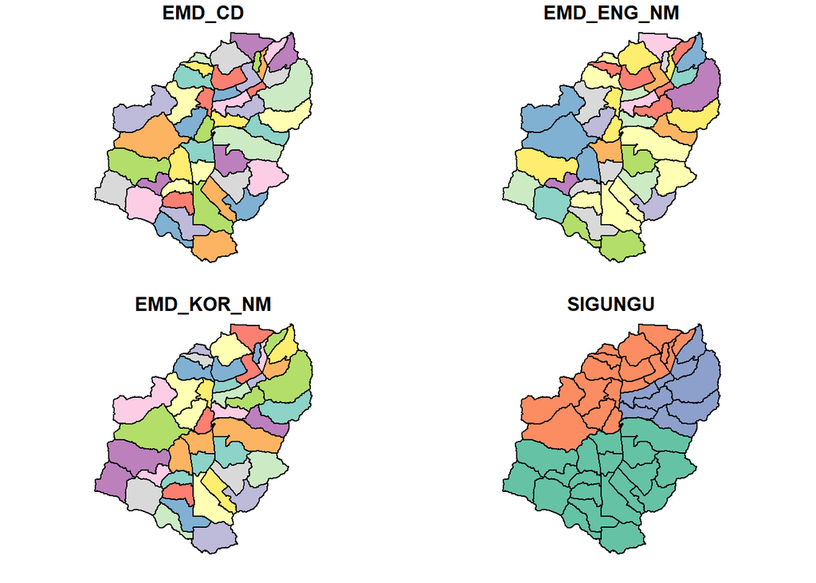

```r
## 인코딩 변경
emd_sf$EMD_KOR_NM <- iconv(emd_sf$EMD_KOR_NM, from = "CP949", to = "UTF-8", sub = NA, mark = TRUE, toRaw = FALSE)

## 좌표계 변경: 웹 메르카도(web mercator)
emd_sf <- st_transform(emd_sf, "+proj=longlat +datum=WGS84")

## 성남시 행정동 코드: 4113000000
sungnam_sf <- emd_sf %>%
  mutate(SIGUNGU = case_when(str_detect(EMD_CD, "^41131") ~ "수정구",
                             str_detect(EMD_CD, "^41133") ~ "중원구",
                             str_detect(EMD_CD, "^41135") ~ "분당구")) %>%
  filter(!is.na(SIGUNGU))

## 시각화
sungnam_sf %>%
  plot()
```

## 2.2 분당구 행정동 `sf` 저장

마지막으로 성남시 시군구 읍면동까지 잘 정리된 `sf` 데이터프레임으로 저장하여 다음 교차분석을 준비한다.

```r
sungnam_sf
```

```
Simple feature collection with 44 features and 4 fields
geometry type:  MULTIPOLYGON
dimension:      XY
bbox:           xmin: 127.0277 ymin: 37.33337 xmax: 127.1958 ymax: 37.47481
epsg (SRID):    4326
proj4string:    +proj=longlat +datum=WGS84 +no_defs
First 10 features:
     EMD_CD     EMD_ENG_NM EMD_KOR_NM SIGUNGU
1  41131101  Sinheung-dong     신흥동  수정구
2  41131102 Taepyeong-dong     태평동  수정구
3  41131103     Sujin-dong     수진동  수정구
4  41131104    Dandae-dong     단대동  수정구
5  41131105  Sanseong-dong     산성동  수정구
6  41131106    Yangji-dong     양지동  수정구
7  41131107  Bokjeong-dong     복정동  수정구
8  41131108  Changgok-dong     창곡동  수정구
9  41131109   Sinchon-dong     신촌동  수정구
10 41131110       Oya-dong     오야동  수정구
                         geometry
1  MULTIPOLYGON (((127.1536 37...
2  MULTIPOLYGON (((127.1227 37...
3  MULTIPOLYGON (((127.1374 37...
4  MULTIPOLYGON (((127.1599 37...
5  MULTIPOLYGON (((127.1544 37...
6  MULTIPOLYGON (((127.161 37....
7  MULTIPOLYGON (((127.129 37....
8  MULTIPOLYGON (((127.1496 37...
9  MULTIPOLYGON (((127.1181 37...
10 MULTIPOLYGON (((127.1068 37...
```

```r
## shapefile 저장
dir.create('data/shapefile/sungnam')
st_write(sungnam_sf, "data/shapefile/sungnam/sungnam_sf.shp", delete_dsn=TRUE)
```

```
Deleting source `data/shapefile/sungnam/sungnam_sf.shp' using driver `ESRI Shapefile'
Writing layer `sungnam_sf' to data source `data/shapefile/sungnam/sungnam_sf.shp' using driver `ESRI Shapefile'
features:       44
fields:         4
geometry type:  Multi Polygon
```